# Asymptote

An attempt to improve docs

Ott Toomet

2022-11-05

# 1 Introduction

Asymptote is an excellent tool to greate more complex editable graphs. However, the documentation is thin and very hard to navigate. Here are some notes.

# 2 Command line usage

## 2.1 Output formats

Output formats can be specified

```
asy -f <format>
```

At least these formats are supported:

- **eps** (default)
- **pdf**
- **jpg**: uses imagemagick to convert to jpg. Ensure you imagemagick policies are permissive enough!
- **png**: uses transparent background

# 3 Data structures

# 4 Drawing

## 4.1 Drawing paths

The main drawing command is `draw`. It most important arguments are

```
draw(path)
```

If the path contains a single pair, it just draws a dot.

## 4.2 Drawing dots

Dots can be drawn with `dot(pair)`. Dots are drawn using the current line width, and the width is magnified by system variable `dotfactor`. For instance:

```cpp
dotfactor=10;
dot((1,2));
dot((2,1));
```

The dot is drawn using the current line width, multiplied but `dotfactor` (default: 6).

# 5 Labels

## 5.1 Labeling points

The basic way to add labels to points is with

```
label(Label L, pair position, align align, pen p, filltype filltype)
```

- **L** is a text string that may contain latex. It may also be a dedicated *Label* object.
- **position** is the point location we are labeling.
- **align** is the location of label with respective to the position. By default, the label is centered at the position. This should be a vector (*pair*) that indicates the position of the closest corner of the lable with respect to the point.

  The defined compas directions are just shortcuts for vectors in that direction. These can be scaled and added (e.g. `2*N + E`), and one can supply other vectors. A useful way to create vectors is function `dir` that creates an unit vector in given direction (in degrees).
- **pen** are typically colors
- **filltype**: the background of a label can be filled with a given color, e.g. you may want to specify `Fill(white)` to add a white background on a label that is on top of obscured by other elements.

The following image demonstrates a few of these tools:

- The first label is attached to the horizontal spoke, East of it. All the pre-defined compas directions can be used in this fashion.
- The second, $30^\circ$ label, is actually labeling the origin, but shifted outside of the circle. This is achieved by multiplying the alignment vector `dir(30)` by 32. This number depends on the size and should be found by experimenting.
- the third label is attached to the `dir(150)` point, however, to the opposite direction (inside of the circle) of it. The background is filled white in order to remove the spoke behind the label.

```r
size(80mm);

draw(unitcircle);
draw((0,0)--(1,0));
/* pre-determined direction 'E' */
label("$0^\circ$", (1,0), E);
draw((0,0)--dir(30));
/* label the origin, shift far to direction of 30deg */
label("$30^\circ$", (0,0), 32*dir(30));
draw((0,0)--dir(150));
/* label the 150deg point, shift to the opposite direction
   fill background white to cover the spike */
label("$150^\circ$", dir(150), -dir(150),
      Fill(white));
```

This results in

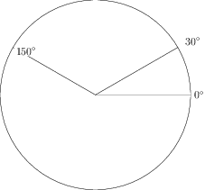

# 6 Frames and pictures

Frames and pictures are a way to repeate certain complex drawings when potentially transforming those in the process.

## 6.1 Pictures

Pictures are, well, pictures.

The following example demonstrates how to create a new picture, and add it to the main picture several times with small modifications. We create the main picture that contains a diagonal line, and another *picture* object that contains a scaled unit circle. Thereafter we a) add the circle-picture on the main picture unchanged, and b) add it second time, scaled and shifted to the end of the diagonal line:

```r
/* set the total size, for all pictures we do */
size(120mm);

/* Draw a diagonal line on the base pic */
draw((0,0)--(1,1));

/* Create a new picture, containing a circle */
picture p = new picture;
draw(p, scale(0.2)*unitcircle);

/* put the circle at the origin */
add(p);
/* put the circle again, shifted and scaled */
add(shift((1,1))*scale(2)*p);
```

This results in

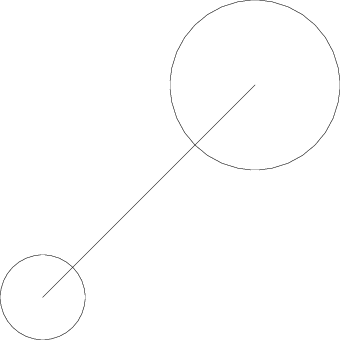

The originally defined *size* applies to the new pictures as well, so adding a new picture will automatically scale in a way that the unit size will be the same as on the original picture.

## 6.2 Frames

Frames are somewhat similar to pictures, but it seems one cannot change *size* or *unitsize* on frames. The result will be in postscript units. However, one can use similar `add` function, and scale frames.

# 7 Coding

## 7.1 Output

Output to console can be done using `write`, it accepts a list of arguments that will be printed, no spaces are inserted between the list items. It can print various *asymptote* data structures, including pairs and paths. See example in Functions.

## 7.2 For loops

There are two types of for loops, both following the java/C++ style. The first one contains the explicit initializer, condition, and increment statement, all separated by semicolons:

```java
for(int i = 0; i < 10; ++i) {
   // do something
}
```

The other is the “variable : collection” syntax to loop over all variables in a collection:

```java
for(pair point : pointlist) {
   // do something
}
```

Note that in both cases the loop variable must be defined inside of the loop operator. The loop variable only exists within the loop and is lost as soon as the loop exits.

## 7.3 Functions

Function definition is fairly similar to function in C++ and java. You have to declare the return type, and argument types. Argument default values are accepted.

Function must return a value–a missing return statement results in an error, unless the return value is declared as *void*.

```r
real multiply(real x, real y=3) {
  real z = x*y;
  return z;
}

write("2*3=", multiply(2));
write("2*4=", multiply(2, 4));
```

The output is:

```
2*3=6
2*4=8
```